# hw_03

lisa liubovich

2024-06-06

# 1 Predicting a grade (CV in KNN)

Do by hand. A student wants to predict their grade for the Statistical Machine Learning course, using the KNN algorithm with *K* = 3. Six friends who took the course last year had the following mid-term test scores and grades.

| Friend | 1 | 2 | 3 | 4 | 5 | 6 |
| --- | --- | --- | --- | --- | --- | --- |
| Midterm | 90 | 88 | 83 | 78 | 85 | 84 |
| Course Grade | A | A | A | B | B | B |

Estimate the prediction error rate of the algorithm, by means of:

1. The validation-set method, using Friends 2, 3, 4, 5 as training and Friends 1, 6 as testing data.

   Training Data: Friends 2, 3, 4, 5

   Testing Data: 1, 6

   Prediction for Friend 1 (Midterm = 90)

   Distance to Friend 2: |90-88| = 2

   Distance to Friend 3: |90-83| = 7

   Distance to Friend 4: |90-78| = 12

   Distance to Friend 5: |90-85| = 5

   Nearest neighbors: 2, 5, and 7 $\rightarrow$ Grades: A, B, A

   The predicted grade for friend 1 is an A.

   Prediction for Friend 6 (midterm = 84)

   Distance to Friend 2: |84-88| = 4

   Distance to Friend 3: |84-83| = 1

   Distance to Friend 4: |84-78| = 6

   Distance to Friend 5: |84-85| = 1

   Nearest neighbors: Friends 3, 5, and 2 $\rightarrow$ Grades: A, B, A

   The predicted grade for friend 6 is an A.

   Error rate: incorrect predictions/total test data = 1/2 = 0.5
2. The leave-one-out cross-validation method.

   Prediction for Friend 1 (Midterm = 90)

   Training: 2, 3, 4, 5, 6

   Distance to Friend 2: |90-88| = 2

   Distance to Friend 3: |90-83| = 7

   Distance to Friend 4: |90-78| = 12

   Distance to Friend 5: |90-85| = 5

   Distance to Friend 6: |90-84| = 6

   Nearest neighbors: 2, 5, and 6 $\rightarrow$ Grades: A, B, B

   The predicted grade for friend 1 is an B, which is incorrect.

   Prediction for Friend 2 (Midterm = 88)

   Training: Friends 1, 3, 4, 5, 6

   Distance to Friend 1: |88-90| = 2

   Distance to Friend 3: |88-83| = 5

   Distance to Friend 4: |88-78| = 10

   Distance to Friend 5: |88-85| = 3

   Distance to Friend 6: |88-84| = 4

   Nearest neighbors: Friends 1, 5, 6 $\rightarrow$ Grades: A, B, B

   The predicted grade for friend 2 is B, which is Incorrect

   Prediction for Friend 3 (Midterm = 83)

   Training: Friends 1, 2, 4, 5, 6

   Distance to Friend 1: 7

   Distance to Friend 3: 5

   Distance to Friend 4: 5

   Distance to Friend 5: 2

   Distance to Friend 6: 1

   Nearest neighbors: Friends 2, 5, 6 $\rightarrow$ Grades: B, B, A

   The predicted grade for friend 3 is B, which is incorrect

   Prediction for Friend 4 (Midterm = 78)

   Training: Friends 1, 2, 3, 5, 6

   Distance to Friend 1: 12

   Distance to Friend 2: 10

   Distance to Friend 3: 5

   Distance to Friend 5: 7

   Distance to Friend 6: 6

   Nearest neighbors: Friends 3, 5, 6 $\rightarrow$ Grades: A, B, B

   The predicted grade for friend 4 is B, which is correct

   Prediction for Friend 5 (Midterm = 85)

   Training: Friends 1, 2, 4, 5, 6

   Distance to Friend 1: 5

   Distance to Friend 2: 3

   Distance to Friend 3: 2

   Distance to Friend 4: 7

   Distance to Friend 6: 1

   Nearest neighbors: Friends 2, 3, 6 $\rightarrow$ Grades: B, A, A

   The predicted grade for friend 5 is A which is incorrect

   Prediction for Friend 6 (Midterm = 84)

   Training: Friends 1, 2, 3, 4, 5

   Distance to Friend 1: 6

   Distance to Friend 2: 4

   Distance to Friend 3: 1

   Distance to Friend 4: 6

   Distance to Friend 5: 1

   Nearest neighbors: Friends 2, 3, 5 $\rightarrow$ Grades: A, B, A

   The predicted grade for friend 6 is A which is incorrect

   Error rate: 5/6 = 0.833
3. (Stat 627) Use knn.cv() function in package class to confirm your computation in (b). (You can start with reading the help file of knn.cv().)

   ```r
   library(class)

   midterm_scores <- c(90, 88, 83, 78, 85, 84)
   grades <- factor(c("A", "A", "A", "B", "B", "B"))

   predicted_grades <- knn.cv(train = midterm_scores, cl = grades, k = 3)

   error_rate <- mean(predicted_grades != grades)
   print(error_rate)
   ```

   ```
   ## [1] 0.8333333
   ```

# 2 Ex.5.4.8. Cross-validation in linear regression on simulated data

1. Generate a simulated data set as follows:

```r
set.seed(1)
x <- rnorm (100)
y <- x - 2*x^2 + rnorm(100)
sim.df <- data.frame(x, y) # data.frame will be helpful in part (b), (c)
```

In this data set, what is *n* and *p*? Write out the model used to generate the data in equation form. Plot the data and interpret the plot.

n = 100, p = 1

Model used to generate data: y = x - 2x<sup>2</sup> + $\varepsilon$ , where $\varepsilon$ is a random error term drawn for a normal distribution $\varepsilon$ ~ N(0,1).

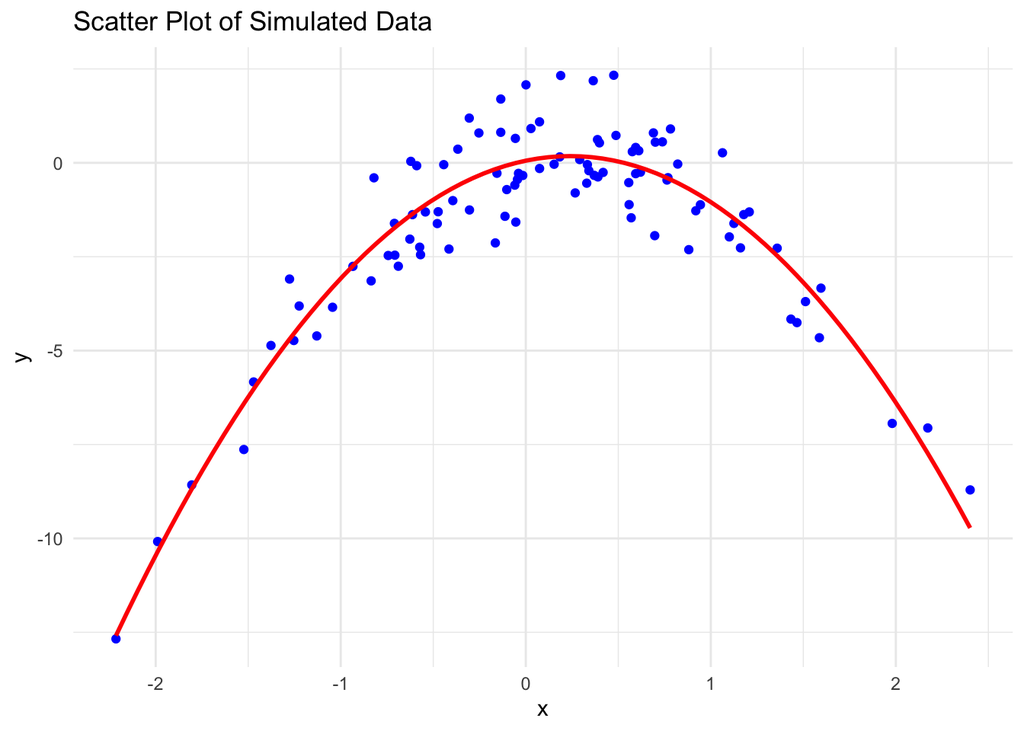

```r
library(ggplot2)
ggplot(sim.df, aes(x = x, y = y)) +
  geom_point(color = "blue") +
  labs(title = "Scatter Plot of Simulated Data",
       x = "x",
       y = "y") +
  theme_minimal() +
  geom_smooth(method = "lm", formula = y ~ poly(x, 2), se = FALSE, color = "red")
```

The curve shows the quadratic trend of the data, which makes sense giving the squared term in the equation. The dispersion of points around the red line is relatively even but a bit wider towards the peak of the parabola, which indicates more significant noise in the data.

2. Compute the LOOCV estimates of prediction error that result from fitting each of the following four regression models: (Hints: (1) LOOCV is the same as K-fold CV with K=(sample size). (2) Use function glm() fits Normal linear regression when you set family=gaussian. (3). Use function cv.glm() in pacakgeboot‘.)

Y = $\beta_0$ + $\beta_1$ X + $\varepsilon$

Y = $\beta_0$ + $\beta_1$ X + $\beta_2$ X<sup>2</sup> + $\varepsilon$

Y = $\beta_0$ + $\beta_1$ X + $\beta_2$ X<sup>2</sup> + $\beta_3$ X<sup>3</sup> + $\varepsilon$

Y = $\beta_0$ + $\beta_1$ X + $\beta_2$ X<sup>2</sup> + $\beta_3$ X<sup>3</sup> + $\beta_4$ X<sup>4</sup> + $\varepsilon$

```r
library(boot)
compute_loocv_error <- function(formula, data) {
  model <- glm(formula, data = data, family = gaussian)
  cv_result <- cv.glm(data, model, K = nrow(data))
  return(cv_result$delta[1])  # LOOCV error
}


formula_1 <- y ~ x
formula_2 <- y ~ x + I(x^2)
formula_3 <- y ~ x + I(x^2) + I(x^3)
formula_4 <- y ~ x + I(x^2) + I(x^3) + I(x^4)


loocv_error_1 <- compute_loocv_error(formula_1, sim.df)
loocv_error_2 <- compute_loocv_error(formula_2, sim.df)
loocv_error_3 <- compute_loocv_error(formula_3, sim.df)
loocv_error_4 <- compute_loocv_error(formula_4, sim.df)


loocv_error_1
```

```
## [1] 7.288162
```

```r
loocv_error_2
```

```
## [1] 0.9374236
```

```r
loocv_error_3
```

```
## [1] 0.9566218
```

```r
loocv_error_4
```

```
## [1] 0.9539049
```

3. Which of these models have the smallest adjusted prediction mean squared error as estimated by LOOCV? Is this what you expected? Explain your answer.

   Model 1 is a simple linear model, which likely underfits the data because the true relationship is quadratic. This explains the relatively high LOOCV error of 7.288162. Model 2 includes a quadratic term, which aligns well with the underlying data-generating process. This model captures the main structure of the data without overfitting, resulting in the smallest LOOCV error. Model 3 and Model 4 add cubic and quartic terms, respectively. These higher-order terms might slightly improve the fit to the data, but they also increase the complexity of the model, which can lead to overfitting and an increase in LOOCV error compared to the simpler quadratic model. This explains why their LOOCV errors (0.9566218 and 0.9539049) are slightly higher than that of Model 2.

   Expected results: The result that Model 2 has the smallest LOOCV error is expected because the data was generated using a quadratic model. Therefore, including the x<sup>2</sup> term should capture the underlying relationship accurately. Model 1’s poor performance is also expected because a linear model cannot capture the curvature of the true quadratic relationship.T he higher LOOCV errors for Model 3 and Model 4 are due to the additional complexity from higher-order polynomial terms, which introduces more variance without significantly reducing bias for this data set. Therefore, the best fit is Model 2 balancing bias and variance effectively. The higher-order models do not provide significant improvement and might even slightly degrade predictive performance due to overfitting.
4. Repeat step b but with *K* = 10-Fold validation and compare the prediction mean squared error. What do you notice compared to LOOCV?

• Use set.seed(12) before **each** cv.glm() call.

```r
compute_10fold_cv_error <- function(formula, data) {
  set.seed(12)  # Ensure reproducibility for each model's CV
  model <- glm(formula, data = data, family = gaussian)
  cv_result <- cv.glm(data, model, K = 10)
  return(cv_result$delta[1])  # 10-Fold CV error
}

formula_1 <- y ~ x
formula_2 <- y ~ x + I(x^2)
formula_3 <- y ~ x + I(x^2) + I(x^3)
formula_4 <- y ~ x + I(x^2) + I(x^3) + I(x^4)


cv_error_1 <- compute_10fold_cv_error(formula_1, sim.df)
cv_error_2 <- compute_10fold_cv_error(formula_2, sim.df)
cv_error_3 <- compute_10fold_cv_error(formula_3, sim.df)
cv_error_4 <- compute_10fold_cv_error(formula_4, sim.df)


cv_error_1
```

```
## [1] 8.205558
```

```r
cv_error_2
```

```
## [1] 0.9457335
```

```r
cv_error_3
```

```
## [1] 1.032554
```

```r
cv_error_4
```

```
## [1] 1.271199
```

Model 2 is the best-performing model based on both LOOCV and 10-fold CV errors. It has the lowest cross-validation errors, reflecting its suitability for capturing the true quadratic relationship in the data. The quadratic model balances bias and variance effectively, providing a good fit to the data without overfitting. Higher-order polynomial models (Models 3 and 4) do not improve performance and may introduce overfitting, as indicated by their higher cross-validation errors.

5. (Stat-627) In part (c) (LOOCV), we did not use set.seed(). In part (d) (10-fold CV), we used set.seed(). The random seed is set so that we can get replicate the the same results for our homework practice. Why is the random seed relevant in the 10-fold CV but not in LOOCV?

The random seed is crucial for 10-fold CV due to the inherent randomness in how the data is split into folds. It ensures that the process can be repeated with the same results, which is key for reproducibility. On the other hand, LOOCV does not require a random seed because the data splitting process is deterministic and consistent across different runs.